# Estudio variabilidad estructural proteica

30/01/2016

## Conjuntos de proteinas

### Conjunto teorico

160 mutantes de 1ifc (131 sitios) simuladas con el modelo mutacional LFENM con ANM *R0* = 12 y *Fmax* = 2 (solo para LFENM). Para determinar que sitios mutar, se alineo 1ifc con cada una de las proteinas del conjunto, se obtuvieron los indices de los sitios alineados pero mutados y se simularon 10 mutantes por cada par de proteinas, obteniendose un total de 160 mutantes. Luego, para el analisis, se tomaron como alineados los sitios alineados de 1ifc para cada par de proteinas.

### Conjunto experimental

16 proteinas de la familia de fabp. Las proteinas tienen un promedio de identidad secuencial de 32%. El core del alineamiento de la familia es de 122 sitios.

La caracterizacion del conjunto experimental se muestra a continuacion:

```
##    pdbid nsites naligned identity      MSD
## 1   1lif    131      129 29.45736 1.898545
## 2  1pmpa    131      129 27.90698 2.085664
## 3   1hmt    131      129 32.55814 1.817272
## 4  1fdqa    131      129 32.55814 2.659980
## 5  1opba    133      129 31.00775 3.545648
## 6  1ggla    134      129 25.58140 3.786735
## 7   1cbs    137      131 32.06107 3.015568
## 8  1cbia    136      131 29.00763 3.482521
## 9  1ftpa    133      128 28.90625 3.205709
## 10 1eioa    127      125 24.00000 5.992160
## 11 3ifba    131      131 81.67939 3.123234
## 12  1b56    133      129 24.03101 2.071997
## 13 1bwya    132      129 31.78295 3.382184
## 14  1crb    134      129 31.00775 2.964872
## 15  1mdc    131      127 19.68504 3.191906
## 16  1lfo    126      124 29.03226 3.415226
```

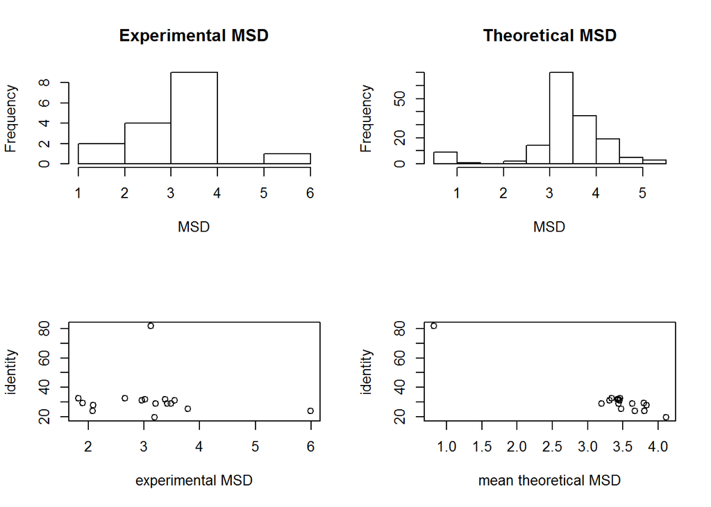

## Comparaciones

### RHO y AUC

Las distribuciones de *auc* y *rho* para cada conjunto se muestran a continuacion (azul= teorico, rojo = experimental)

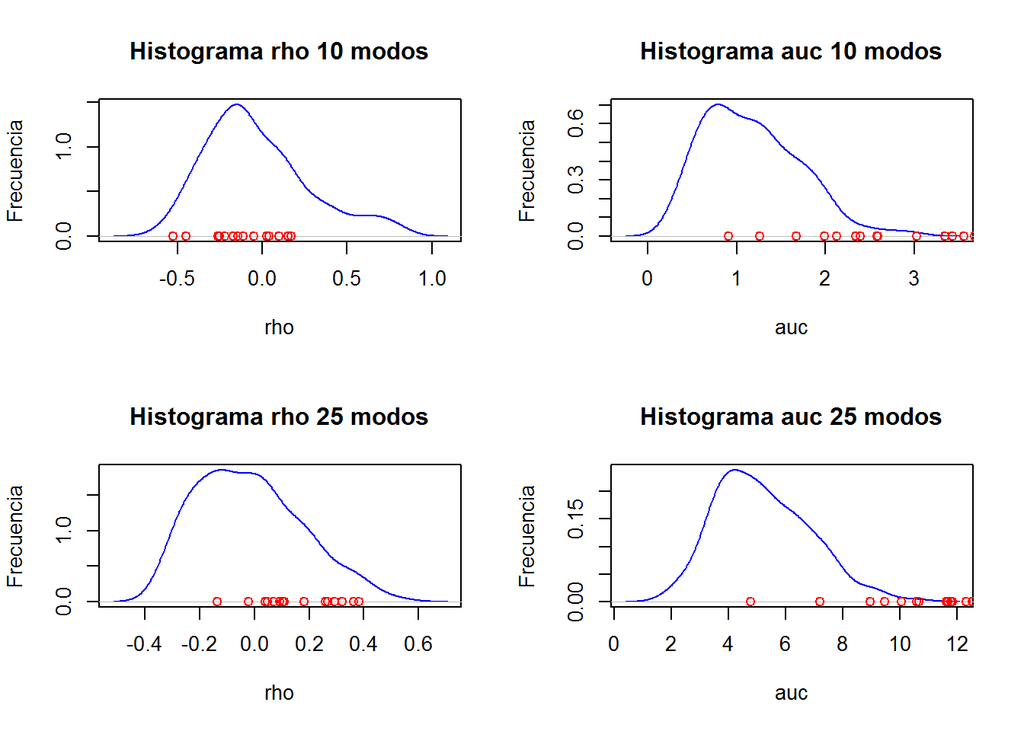

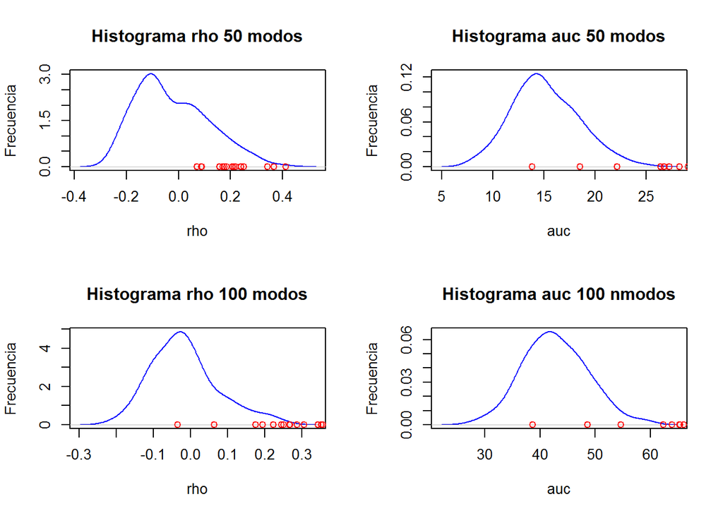

## Pn y Qn

Las distribuciones de *Pn* y *Qn* de los conjuntos son las siguientes:

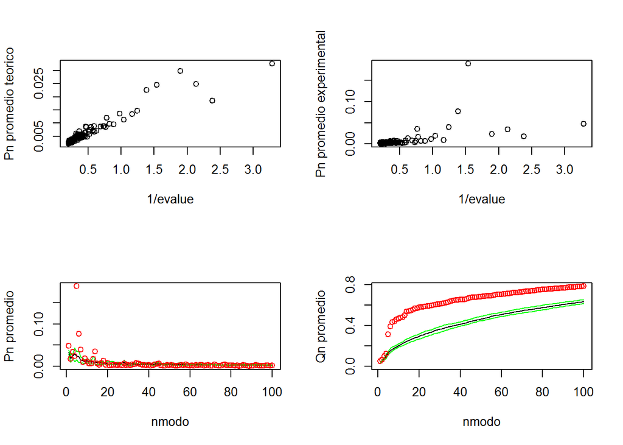

Negro: Teorico Rojo: Experimental Verdes: Cuartiles 0.05 y 0.95 de 10 grupos de 16 mutantes teoricas.